```r
library(caret)   #Machine learning package
library(rattle) #Fancy tree diagram
```

```r
#Needed to install older version of Rgtk2 dependency to get this to work
library(GGally)
library(ggplot2)
library(rpart)
library(randomForest)
```

## Project Goal

#### The goal of your project is to predict the manner in which they did the exercise.

#### This is the “classe” variable in the training set.

#### You may use any of the other variables to predict with.

#### You should create a report describing how you built your model,

#### how you used cross validation, what you think the expected out of sample error is,

#### and why you made the choices you did.

#### You will also use your prediction model to predict 20 different test cases.

### Step 1. Load data into R and break it down into training and test cases. The 70% train 30% test rule of thumb will be used for the division of data.

```r
if(exists("Training")==FALSE){
  Training<-read.csv("https://d396qusza40orc.cloudfront.net/predmachlearn/pml-training.csv")
  Test<-read.csv("https://d396qusza40orc.cloudfront.net/predmachlearn/pml-testing.csv")
}

Training[Training==""] <- NA
trainingData<-Training[,8:160]
trainingData<-trainingData[,is.na(trainingData[1,])==FALSE] #Remove columns that have no data

#Break Data down into training/test sets (70/30%)
testIndex = createDataPartition(trainingData$classe, p = 0.70,list=FALSE)
trainingSet = trainingData[testIndex,]
testingSet = trainingData[-testIndex,]
```

### Step 2. Use the caret package to fit a predictive model to the data. For the first attempt the “rpart” model will be used.

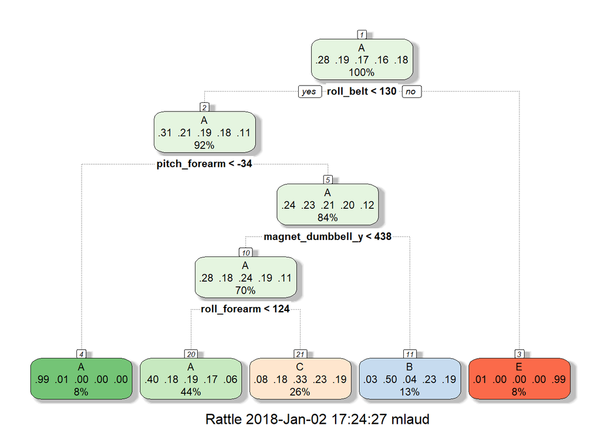

```r
modFit<-train(classe~.,method="rpart",data=trainingSet, na.action = na.omit) #"train" is predictive model from caret program
fancyRpartPlot(modFit$finalModel)
```

```r
print(modFit$finalModel)
```

```
## n= 13737
##
## node), split, n, loss, yval, (yprob)
##       * denotes terminal node
##
##  1) root 13737 9831 A (0.28 0.19 0.17 0.16 0.18)
##    2) roll_belt< 130.5 12591 8692 A (0.31 0.21 0.19 0.18 0.11)
##      4) pitch_forearm< -33.95 1099    8 A (0.99 0.0073 0 0 0) *
##      5) pitch_forearm>=-33.95 11492 8684 A (0.24 0.23 0.21 0.2 0.12)
##       10) magnet_dumbbell_y< 437.5 9680 6931 A (0.28 0.18 0.24 0.19 0.11)
##         20) roll_forearm< 123.5 6076 3616 A (0.4 0.18 0.19 0.17 0.059) *
##         21) roll_forearm>=123.5 3604 2421 C (0.08 0.18 0.33 0.23 0.19) *
##       11) magnet_dumbbell_y>=437.5 1812  897 B (0.033 0.5 0.044 0.23 0.19) *
##    3) roll_belt>=130.5 1146    7 E (0.0061 0 0 0 0.99) *
```

### Step 3. Use the rpart model to predict new data and determine its accuracy. Also provide a visual display of the critical factor interaction to provide a more visceral understanding of the data.

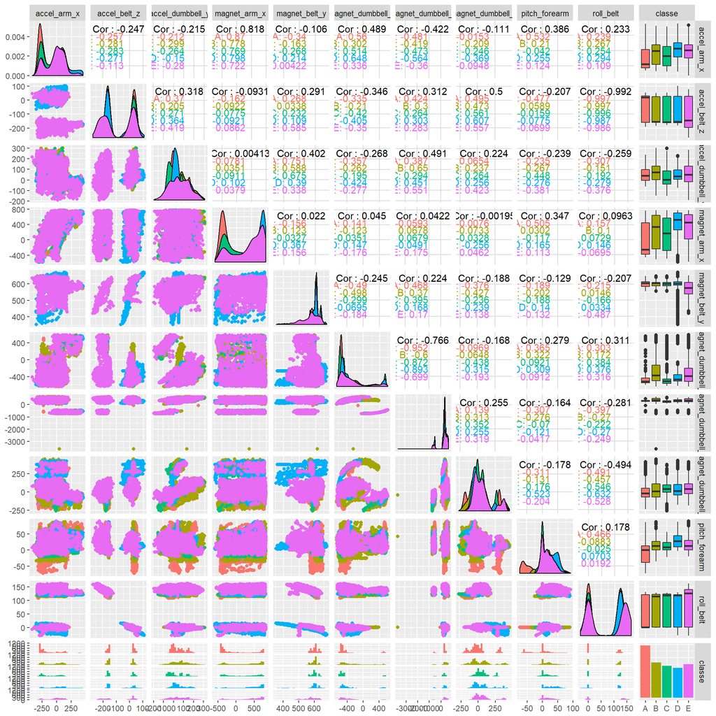

```r
VariableImp<-varImp(modFit)

#determine most important variables and plot graphical pairs
Imp<-rownames(VariableImp$importance[1:10,,drop=FALSE])
ImpTrainSet<-trainingSet[,Imp]
ggpairs(trainingSet[,c(Imp,"classe")],aes(color=classe))
```

```r
classepredict=predict(modFit,testingSet,data = na.omit(data))
#confusionMatrix(testingSet$Classe,classepredict) #Does not work because "D" is never predicted workaround below
table(factor(classepredict, levels=min(testingSet$classe):max(testingSet$classe)), factor(testingSet$classe, levels=min(testingSet$classe):max(testingSet$classe)))
```

[output not shown]

```r
u = union(classepredict, testingSet$classe)
t = table(factor(classepredict, u), factor(testingSet$classe, u))
confusionMatrix(t)
```

```
## Confusion Matrix and Statistics
##
##
##        A    C    E    B    D
##   A 1523  452  164  461  422
##   C  113  544  274  297  382
##   E    7    0  492    0    0
##   B   31   30  152  381  160
##   D    0    0    0    0    0
##
## Overall Statistics
##
##                Accuracy : 0.4996
##                  95% CI : (0.4867, 0.5124)
##     No Information Rate : 0.2845
##     P-Value [Acc > NIR] : < 2.2e-16
##
##                   Kappa : 0.3466
##  Mcnemar's Test P-Value : NA
##
## Statistics by Class:
##
##                      Class: A Class: C Class: E Class: B Class: D
## Sensitivity            0.9098  0.53021  0.45471  0.33450   0.0000
## Specificity            0.6440  0.78061  0.99854  0.92141   1.0000
## Pos Pred Value         0.5040  0.33789  0.98597  0.50531      NaN
## Neg Pred Value         0.9473  0.88725  0.89046  0.85227   0.8362
## Prevalence             0.2845  0.17434  0.18386  0.19354   0.1638
## Detection Rate         0.2588  0.09244  0.08360  0.06474   0.0000
## Detection Prevalence   0.5135  0.27358  0.08479  0.12812   0.0000
## Balanced Accuracy      0.7769  0.65541  0.72663  0.62796   0.5000
```

### Step 4. The rpart model only achieved a 49% accuracy based on the confusion matrix. It’s possible to take two differing approaches at this point. Either try to tune the existing model or explore other potential models. Due to the poor fit of the first model, the latter approach will be explored first.

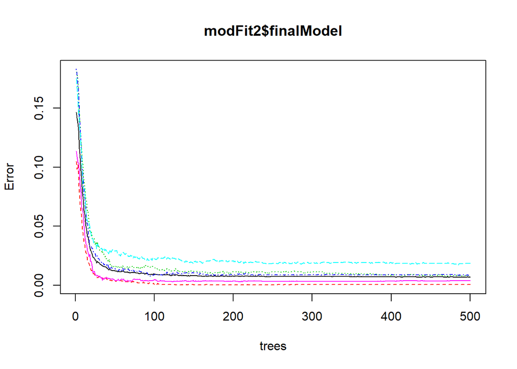

```r
modFit2<-train(classe~.,method="rf",data=trainingSet, na.action = na.omit) #"train" is predictive model from caret program
plot(modFit2$finalModel)
```

```r
print(modFit2$finalModel)
```

```
##
## Call:
##  randomForest(x = x, y = y, mtry = param$mtry)
##                Type of random forest: classification
##                      Number of trees: 500
## No. of variables tried at each split: 2
##
##         OOB estimate of  error rate: 0.7%
## Confusion matrix:
##      A    B    C    D    E  class.error
## A 3904    1    0    0    1 0.0005120328
## B   19 2636    3    0    0 0.0082768999
## C    0   18 2376    2    0 0.0083472454
## D    0    0   39 2210    3 0.0186500888
## E    0    0    3    7 2515 0.0039603960
```

```r
VariableImp<-varImp(modFit2)

#determine most important variables and plot graphical pairs
Imp<-rownames(VariableImp$importance[1:10,,drop=FALSE])
ImpTrainSet<-trainSet[,Imp]
```

[output not shown]

```r
classepredict=predict(modFit2,testingSet,data = na.omit(data))
#confusionMatrix(testingSet$Classe,classepredict) #Does not work because "D" is never predicted workaround below
table(factor(classepredict, levels=min(testingSet$classe):max(testingSet$classe)), factor(testingSet$classe, levels=min(testingSet$classe):max(testingSet$classe)))
```

[output not shown]

```r
u = union(classepredict, testingSet$classe)
t = table(factor(classepredict, u), factor(testingSet$classe, u))
confusionMatrix(t)
```

```
## Confusion Matrix and Statistics
##
##
##        A    B    C    D    E
##   A 1674   15    0    0    0
##   B    0 1120    4    0    0
##   C    0    4 1022   15    0
##   D    0    0    0  949    4
##   E    0    0    0    0 1078
##
## Overall Statistics
##
##                Accuracy : 0.9929
##                  95% CI : (0.9904, 0.9949)
##     No Information Rate : 0.2845
##     P-Value [Acc > NIR] : < 2.2e-16
##
##                   Kappa : 0.991
##  Mcnemar's Test P-Value : NA
##
## Statistics by Class:
##
##                      Class: A Class: B Class: C Class: D Class: E
## Sensitivity            1.0000   0.9833   0.9961   0.9844   0.9963
## Specificity            0.9964   0.9992   0.9961   0.9992   1.0000
## Pos Pred Value         0.9911   0.9964   0.9817   0.9958   1.0000
## Neg Pred Value         1.0000   0.9960   0.9992   0.9970   0.9992
## Prevalence             0.2845   0.1935   0.1743   0.1638   0.1839
## Detection Rate         0.2845   0.1903   0.1737   0.1613   0.1832
## Detection Prevalence   0.2870   0.1910   0.1769   0.1619   0.1832
## Balanced Accuracy      0.9982   0.9912   0.9961   0.9918   0.9982
```

### The confusion matrix shows the default random forest model has a high sensitivity and specificity at the expense of being much more computational intensive. This level of accuracy should be sufficient for the current assignment.

### Step 5. Use the new model to predict the next 20 test cases.

```r
pred<- predict(modFit2, newdata=Test)
pred
```

```
##  [1] B A B A A E D B A A B C B A E E A B B B
## Levels: A B C D E
```